# Smartwatch useage analysis

Wouter Driessen

2023-03-23

The business objective is to analyze smart device fitness data to gain insight into consumers usage patterns and use these insights to guide the marketing strategy of a company that manufactures health-focused products. The analysis aims to unlock new growth opportunities and enable the company to become a major player in the global smart device market. Specifically, the goal is to focus on one of the company’s products and examine smart device usage data to identify trends that could be applied to inform marketing strategy and better serve Bellabeat’s customers.

```r
heartrate_seconds <- read.csv("heartrate_seconds_merged.csv")
hourly_calories <- read.csv("hourlyCalories_merged.csv")
daily_activity <- read.csv("dailyActivity_merged.csv")
daily_calories <- read.csv("dailyCalories_merged.csv")
daily_intensities <- read.csv("dailyIntensities_merged.csv")
daily_steps <- read_csv("dailySteps_merged.csv")
hourly_intensities <- read_csv("hourlyIntensities_merged.csv")
hourly_steps <- read.csv("hourlySteps_merged.csv")
minute_calories_narrow<- read.csv("minuteCaloriesNarrow_merged.csv")
minute_intensities_narrow <- read_csv("minuteIntensitiesNarrow_merged.csv")
minute_met_narrow <- read_csv("minuteMETsNarrow_merged.csv")
minute_sleep <- read.csv("minuteSleep_merged.csv")
minute_steps_narrow <- read_csv("minuteStepsNarrow_merged.csv")
minute_steps_wide<- read.csv("minuteStepsWide_merged.csv")
sleep_day <- read.csv("sleepDay_merged.csv")
weight_log <- read_csv("weightLogInfo_merged.csv")
```

#### Data aggregation:

Data aggregation in 3 categories based on timescale. It creates three distinct data frames: ‘daily’, ‘hourly’, and ‘minute’.The data aggragetes give a more comprehensive insight into individuals’ fitness and activity patterns through inner joins on common columns like ‘Id’, ‘ActivityDate’, ‘ActivityHour’, and ‘ActivityMinute’. This format makes the data more accessible for further analysis.

```r
daily <- daily_activity %>%
  inner_join(daily_calories,by=c("Id","Calories","ActivityDate" = "ActivityDay")) %>%
  inner_join(daily_intensities,by=c("Id","VeryActiveDistance","ModeratelyActiveDistance",
                                    "LightActiveDistance","SedentaryActiveDistance",
                                    "VeryActiveMinutes","FairlyActiveMinutes",
                                    "LightlyActiveMinutes","SedentaryMinutes",
                                    "ActivityDate" = "ActivityDay")) %>%
  inner_join(daily_steps,by=c("Id", "ActivityDate" = "ActivityDay"))


hourly <- hourly_calories %>% inner_join(hourly_intensities,by=c("Id","ActivityHour")) %>%
  inner_join(hourly_steps,by=c("Id","ActivityHour"))

minute <- minute_calories_narrow %>% inner_join(minute_intensities_narrow,by=c("Id","ActivityMinute")) %>%
  inner_join(minute_met_narrow,by=c("Id","ActivityMinute")) %>%
  inner_join(minute_steps_narrow,by=c("Id","ActivityMinute"))
```

After the data was joined together in 3 distinct data frames, any unnecessary data was removed from the environment to tidy up the work space.

```r
#clean up environment
rm(daily_activity,daily_calories,daily_intensities,daily_steps,minute_calories_narrow,minute_intensities_narrow,minute_met_narrow,minute_steps_narrow,hourly_calories,hourly_intensities,hourly_steps)
```

#### Data cleaning: removal of duplicates

The data frames were inspected for duplicate entries and removed upon identification.

```r
count(daily)
count(distinct(daily))
count(hourly)
count(distinct(hourly))
count(minute)
count(distinct(minute))
count(weight_log)
count(distinct(weight_log))
count(sleep_day)
count(distinct(sleep_day)) #found  duplicate rows
sleep_day <- distinct(sleep_day) #romove duplicates
```

#### Data cleaning: formatting variable names

The variable names were reformatted to improve the consistency and readability of the data.

```r
daily <- clean_names(daily)
hourly <- clean_names(hourly)
minute <- clean_names(minute)
sleep_day <- clean_names(sleep_day)
weight_log <- clean_names(weight_log)
```

#### Data cleaning: changing the character to data type

The overview of the data structure showed that the dates were stored as character types. To enhance their usability, the dates were converted into the date data type.

```r
daily$activity_date <- mdy(daily$activity_date)
format(daily$activity_date, format = "%Y-%m-%d")
hourly$activity_hour <- mdy_hms(hourly$activity_hour)
format(hourly$activity_hour,format="%Y-%m-%d %H:%M:%S")
sleep_day$sleep_day <- mdy_hms(sleep_day$sleep_day)
format(sleep_day$sleep_day,format="%Y-%m-%d %H:%M:%S")
minute$activity_minute <- mdy_hms(minute$activity_minute)
format(minute$activity_minute,format="%Y-%m-%d %H:%M:%S")
```

### Data exploration of funcionality types

Three data frames were created, each containing the counts of days that individuals made use of different functionality types. These data frames were then joined together using a full join operation. The ‘summarise’ function was applied to calculate the average number of days per functionality type. Finally, the results were displayed in a bar graph.

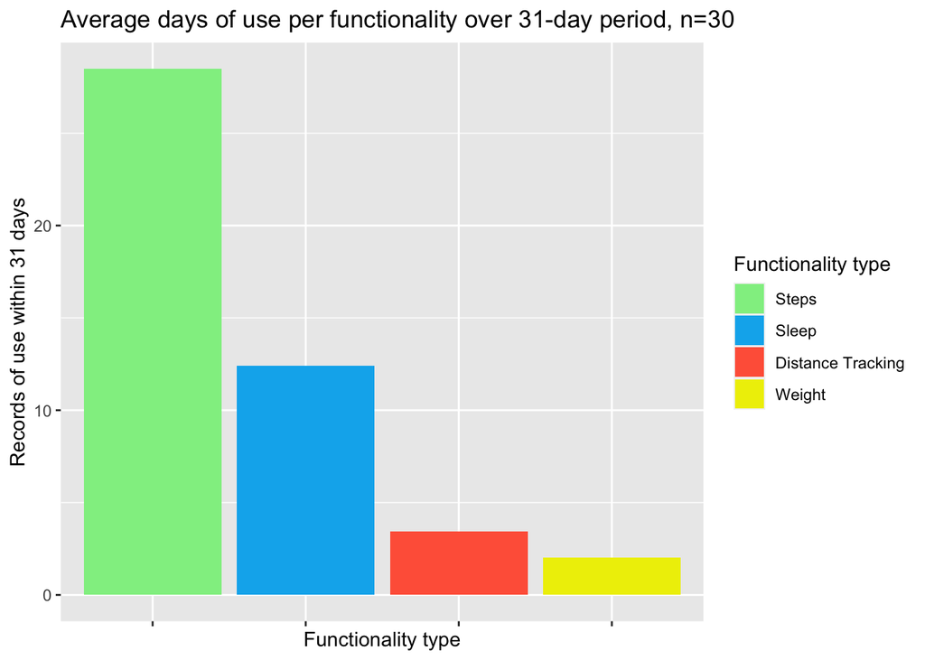

```r
# The ifelse function counts the elements that are higher than 0 for each individual resulting in the days that every individual made use of the function
df1 <- daily %>%
  group_by(id) %>%
  summarise(step = ifelse(sum(total_steps) > 0, n(), 0),                # Calculates the count of usage of the steps function
  distance_track = ifelse(sum(logged_activities_distance) > 0, n(), 0)) # Calculates the count of usage of the distance track                                                                          function

df2 <- sleep_day %>%
  group_by(id) %>% summarise(count_sleep=n())                           #Calculates the count of usage of the sleep function
df3 <- weight_log %>% group_by(id) %>% summarise(counts_weight=n())     #Calculates the count of usage of the weights                                                                                  function
# Joining the groups
Usage_by_group <- df1 %>%
  full_join(df2,by="id") %>%
  full_join(df3,by="id") %>%
  replace_na(list(step = 0, distance_track = 0, count_sleep = 0, counts_weight = 0)) # replacing the na for 0 values


# Color choice
c1 <- "palegreen2"
c2 <- "deepskyblue2"
c3 <- "tomato1"
c4 <- "yellow2"

# Bar graph of the avarage use per functionality in a 31-day period.
Usage_by_group %>%
  select(step, count_sleep, counts_weight, distance_track) %>%
  summarise(avg_step = mean(step), # calculates avarge days of use in a 31 day period
            avg_sleep = mean(count_sleep),
            avg_weight = mean(counts_weight),
            avg_distance_track = mean(distance_track)) %>%
  gather(key = "variable", value = "count") %>%
  mutate(variable = factor(variable, levels = c("avg_step", "avg_sleep", "avg_distance_track", "avg_weight"))) %>% # creating factors of the variables in order to display the legend in the correct order
  ggplot(aes(x = reorder(variable, -count), y = count, fill = variable)) +
    geom_col() +
    scale_fill_manual(values = c("avg_step" = c1 , "avg_sleep" = c2, "avg_distance_track" = c3, "avg_weight" = c4),
                      labels = c("Steps", "Sleep", "Distance Tracking", "Weight")) +
    labs(title = "Average days of use per functionality over 31-day period, n=30",
         x = "Functionality type",
         y = "Records of use within 31 days") +
    guides(fill = guide_legend(title = "Functionality type")) + # adds a title to the legend
    theme(axis.text.x = element_blank()) # removes the variable names on the x-axis
```

#### Interpretation: The bar graph indicates that steps usage is the highest among the functionality types, with over twice the usage compared to the second most used functionality, Sleep. Distance tracking and weight functionality were both used for fewer than 5 days on average. This suggests that steps and sleep are the most prioritized functionalities, while distance tracking and weight management are less frequently utilized. These insights can inform future enhancements and developments for these functionalities.

### Data exploration of activity intensity:

The distance tracking function tracks the intensity of use. To analyze any overtime patterns in the intensity of use, the average daily distance traveled for different intensity categories over time was visualized with a line graph. The graph includes blue rectangles to highlight weekends, enabling the identification of distinctive patterns or differences in average daily distance traveled between weekends and weekdays.

[figure not shown]

```r
# Group the data by activity date and calculate the average distances for different intensity categories
daily %>%
  group_by(day = activity_date) %>%
  summarise(
    avg_very_active = mean(very_active_distance),
    avg_moderately_active = mean(moderately_active_distance),
    avg_light_active = mean(light_active_distance),
    avg_sedentary_active = mean(sedentary_active_distance)
  ) %>%
  ggplot(aes(x = day)) +
  # Plotting lines for each intensity category
  geom_line(aes(y = avg_very_active, color = "High Intensity")) +
  geom_line(aes(y = avg_moderately_active, color = "Moderate Intensity")) +
  geom_line(aes(y = avg_light_active, color = "Low Intensity")) +
  # Highlighting weekends with rectangles
  geom_rect(
    aes(xmin = as.Date("2016-04-16"), xmax = as.Date("2016-04-17"), ymin = -Inf, ymax = Inf),
    fill = "lightblue",
    alpha = 0.03
  ) +
  geom_rect(
    aes(xmin = as.Date("2016-04-23"), xmax = as.Date("2016-04-24"), ymin = -Inf, ymax = Inf),
    fill = "lightblue",
    alpha = 0.03
  ) +
  geom_rect(
    aes(xmin = as.Date("2016-04-30"), xmax = as.Date("2016-05-01"), ymin = -Inf, ymax = Inf),
    fill = "lightblue",
    alpha = 0.03
  ) +
  geom_rect(
    aes(xmin = as.Date("2016-05-07"), xmax = as.Date("2016-05-08"), ymin = -Inf, ymax = Inf),
    fill = "lightblue",
    alpha = 0.03
  ) +
  # Manually setting colors and labels for legend
  scale_color_manual(
    values = c("High Intensity" = "red", "Moderate Intensity" = "green", "Low Intensity" = "blue"),
    labels = c("High Intensity", "Moderate Intensity", "Low Intensity")
  ) +
  # Setting plot titles and axis labels
  labs(
    title = "Average Daily Distance Traveled by Intensity Categories, \nwith Weekends Highlighted in Blue",
    x = "Date",
    y = "Average Daily Distance Traveled (in Miles)",
    color = "User Category"
  )
```

#### data exploration of activity of different user types per hour

To conduct a more detailed analysis of usage patterns, the data was categorized into three groups based on the distribution of individual step counts: lightly active, moderately active, and highly active. The mean number of steps per hour was then plotted against the time of day, resulting in a line graph that illustrates the average steps taken per hour for each activity category. This graph provides insights into the variations in step count patterns throughout the day for the three activity categories.

```r
# This code calculates the mean total steps for each 'id' in the 'hourly' dataset. It then arranges the mean step totals in ascending order and uses the quantile function to divide the data into three equal groups based on the 33rd and 66th percentiles.
hourly %>%
  group_by(id) %>%
  summarize(mean_step_total = mean(step_total)) %>%
  arrange(mean_step_total) %>%
  pull(mean_step_total) %>%
  quantile(probs = c(0.33, 0.66))
```

```
##      33%      66%
## 245.8118 365.7832
```

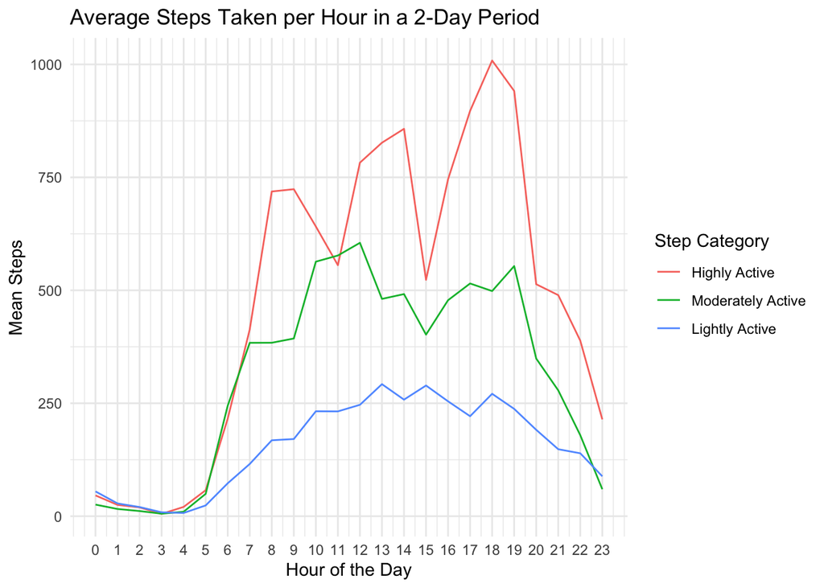

```r
hourly_activity <- hourly %>%
  group_by(id) %>%
  summarize(mean_step_total = mean(step_total)) %>%
  mutate(step_category = case_when(
    mean_step_total < 245.8118 ~ "Lightly Active",
    mean_step_total >=245.8118 & mean_step_total < 365.7832 ~ "Moderately Active",
    mean_step_total > 365.7832 ~ "Highly Active"))


# "This code calculates the mean total steps for each 'id' in the 'hourly' dataset. It then assigns a step category to each 'id' based on their mean step total using the 'case_when' function. The categories are 'Lightly Active' for mean step totals below 245.8118, 'Moderately Active' for mean step totals between 245.8118 and 365.7832, and 'Highly Active' for mean step totals above 365.7832."
hourly %>%
  left_join(hourly_activity, by = "id") %>%
  mutate(hour = hour(activity_hour)) %>%
  group_by(step_category, hour) %>%
  summarise(mean_steps = mean(step_total)) %>%
  mutate(step_category = factor(step_category, levels = c("Highly Active", "Moderately Active", "Lightly Active"))) %>%
  ggplot(aes(x = hour, y = mean_steps, color = step_category)) +
  geom_line() +
  scale_x_continuous(breaks = seq(0, 23, by = 1)) +
  labs(x = "Hour", y = "Mean Steps", color = "Step Category") +
  theme_minimal() +
  labs(
    title = "Average Steps Taken per Hour in a 2-Day Period",
    x = "Hour of the Day",
    y = "Mean Steps",
    color = "Step Category"
  )
```

#### Interpretation

The analysis of step count data for the smartwatch company reveals distinct patterns among different user groups. Highly active and moderately active users display significant peaks and drops throughout the day, while lightly active users exhibit a more gradual change in step count. These patterns suggest that highly active users likely have physically demanding activities or jobs, while moderately and lightly active users may be engaged in more sedentary occupations.

To explore the potential relationship between sleep time and sedentary behavior, the data was categorized into three groups based on the distribution of sedentary time spent per individual: low sedentary, moderately sedentary, and high sedentary. Boxplots were constructed to compare the sleep time across these groups, providing visual representations of the differences in sleep duration among the sedentary categories.

```r
# Calculating quantiles for mean_sedentary_minutes
daily %>%
  group_by(id) %>%
  summarise(
    mean_sedentary_minutes = mean(sedentary_minutes)
  ) %>%
  inner_join(
    sleep_day %>%
      group_by(id) %>%
      summarise(mean_total_min_asleep = mean(total_minutes_asleep))
  ) %>%
  arrange(mean_sedentary_minutes) %>%
  pull(mean_sedentary_minutes) %>%
  quantile(probs = c(0.33, 0.66))
```

```
##       33%       66%
##  761.5051 1066.4462
```

```r
# Creating daily_sleep data frame
daily_sleep <- daily %>%
  group_by(id) %>%
  summarise(
    mean_sedentary_minutes = mean(sedentary_minutes)
  ) %>%
  inner_join(
    sleep_day %>%
      group_by(id) %>%
      summarise(mean_total_min_asleep = mean(total_minutes_asleep))
  ) %>%
  mutate(sedentary_time_category = case_when(
    mean_sedentary_minutes < 762 ~ "low sedentary",
    mean_sedentary_minutes >= 762 & mean_sedentary_minutes < 1066 ~ "moderately sedentary",
    mean_sedentary_minutes >= 1066 ~ "high sedentary"
  )) %>%
  select(sedentary_time_category, mean_total_min_asleep, mean_sedentary_minutes)
```

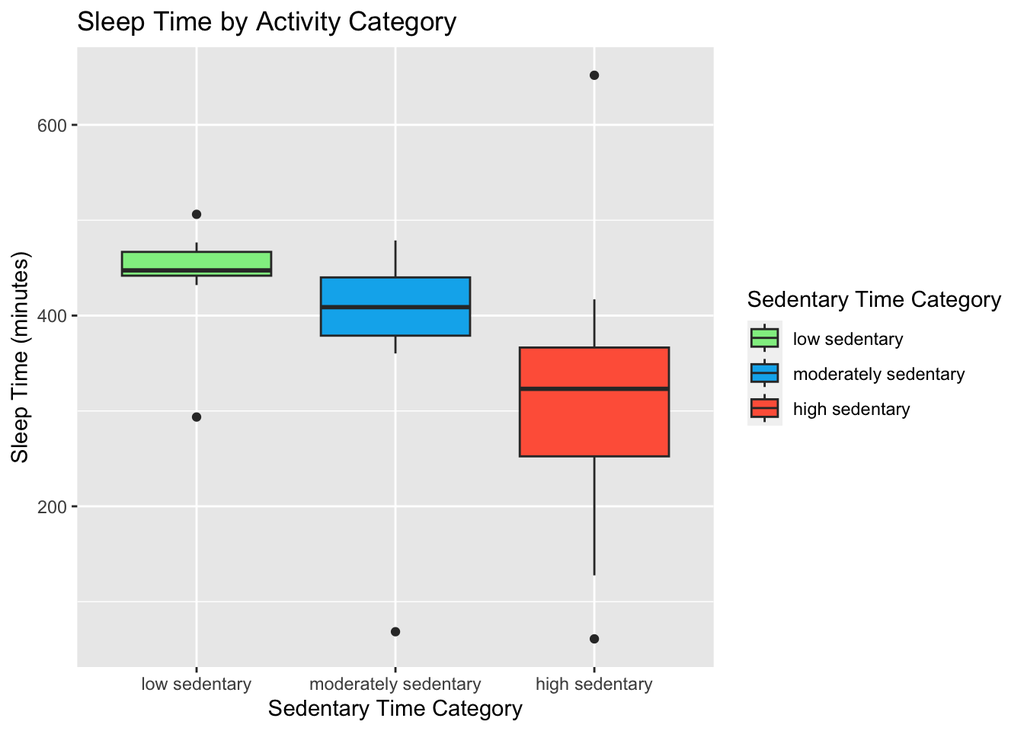

```r
# Change the order of factor levels
daily_sleep$sedentary_time_category <- factor(daily_sleep$sedentary_time_category, levels = c("low sedentary", "moderately sedentary", "high sedentary"))

# Creating a box plot
ggplot(daily_sleep, aes(x = sedentary_time_category, y = mean_total_min_asleep, fill = sedentary_time_category)) +
  geom_boxplot() +
  xlab("Sedentary Time Category") +
  ylab("Sleep Time (minutes)") +
  ggtitle("Sleep Time by Activity Category") +
  scale_fill_manual(values = c(c1, c2, c3)) +
  guides(fill = guide_legend(title = "Sedentary Time Category"))
```

```r
# Performing Kruskal-Wallis test and post hoc Dunn's test
kruskal.test(mean_total_min_asleep ~ sedentary_time_category, data = daily_sleep)
```

```
##
##  Kruskal-Wallis rank sum test
##
## data:  mean_total_min_asleep by sedentary_time_category
## Kruskal-Wallis chi-squared = 5.615, df = 2, p-value = 0.06036
```

```r
dunnTest(daily_sleep$mean_total_min_asleep, daily_sleep$sedentary_time_category, method = "bonferroni")
```

```
## Dunn (1964) Kruskal-Wallis multiple comparison
##   p-values adjusted with the Bonferroni method.
```

```
##                              Comparison         Z    P.unadj      P.adj
## 1        high sedentary - low sedentary -2.368808 0.01784553 0.05353659
## 2 high sedentary - moderately sedentary -1.237437 0.21592494 0.64777482
## 3  low sedentary - moderately sedentary  1.131371 0.25789904 0.77369711
```

#### Interpretation

The boxplots comparing sleep time across three categories of sedentary behavior (low sedentary, moderately sedentary, high sedentary) reveal a clear trend. The low sedentary group has the highest sleep time, followed by the moderately sedentary group. Although the p-value (0.05353659) comparing the low and high sedentary groups is not statistically significant, the trend strongly suggests a relationship between sedentary behavior and sleep time. The relatively small sample size of 8 individuals per group may have contributed to the insignificant results. Further research with larger sample sizes is needed to draw more conclusive findings.

### Conclusion

The analysis of smart device fitness data has provided valuable insights into consumer usage patterns and has the potential to guide the marketing strategy of the health-focused products company for women, enabling them to tap into new growth opportunities in the global smart device market. Key findings include the prioritization of steps and sleep functionalities, lower utilization of distance tracking and weight management functionalities, variations in usage patterns across intensity categories, and a potential relationship between sedentary behavior and sleep time.

#### Recommendations:

1. Enhancing Steps and Sleep Functionalities: Based on the high utilization of steps and sleep functionalities, the company should prioritize further enhancing these features to meet customer needs. This can involve developing new features, improving accuracy, and offering personalized insights or recommendations based on the collected data.
2. Sedentary Reminder: Implement reminders for users with sedentary occupations, encouraging regular movement breaks and exercises to counteract prolonged sitting and promote better health.
3. Expansion of features that focus on weekend activities: Active users could be stimulated by features like relaxation techniques, recovery monitoring, or guided low-intensity workouts. whereas lesser active users could be stimulated to perofom more active activities.
4. Further Research: Expand the analysis by gathering a larger sample size to increase statistical power and improve the significance of the findings. This will help uncover more robust insights and strengthen the validity of the conclusions drawn.

By implementing these recommendations, Bellabeat can optimize its marketing strategy, improve user satisfaction, and position itself as a major player in the global smart device market.